# ChIP-Seq Analysis

Jessica Murphy

April 9, 2019

### Overview

The following data is from a transcription factor ChIP-Seq experiment that looked at DNA binding to androgen receptors (AR). ChIP-seq was performed on two biological replicates from a human bladder cancer cell line. A control ChIP(with IgG)-Seq was performed as well.

### Peak Calling

Peaks were called for the two ChIP samples to determine which areas of the genome were interacting/binding with the receptors. MACS2 was used with the following code.

`macs2 callpeak -t "/BIOS6660/Homework8/data/chip1.markdup.bam" -c "/BIOS6660/Homework8/data/input.markdup.bam" -g hs -n chip1_peaks -f bam --keep-dup auto --bdg` `macs2 callpeak -t "/BIOS6660/Homework8/data/chip2.markdup.bam" -c "/BIOS6660/Homework8/data/input.markdup.bam" -g hs -n chip2_peaks -f bam --keep-dup auto --bdg`

The results are located on Yampa under: /BIOS6660/Homework8/data/

### Peak Annotation

The promoter regions were determined and the distance between the peaks and the promoter regions are shown in the graph below.

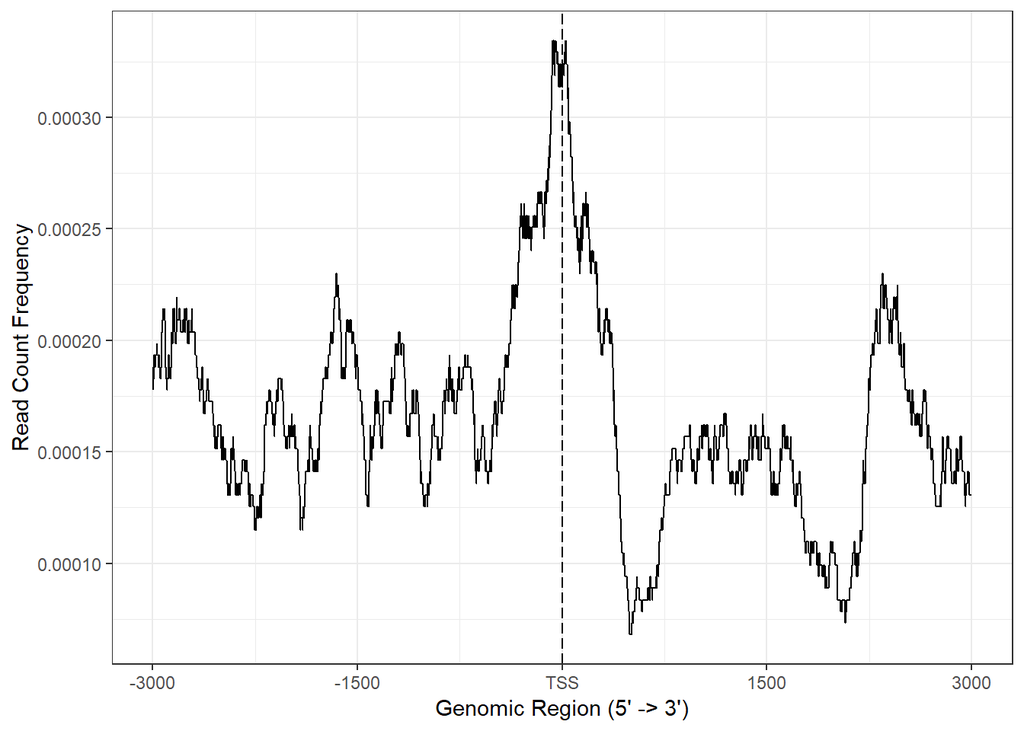

The peaks were then annotated and the results can be seen below.

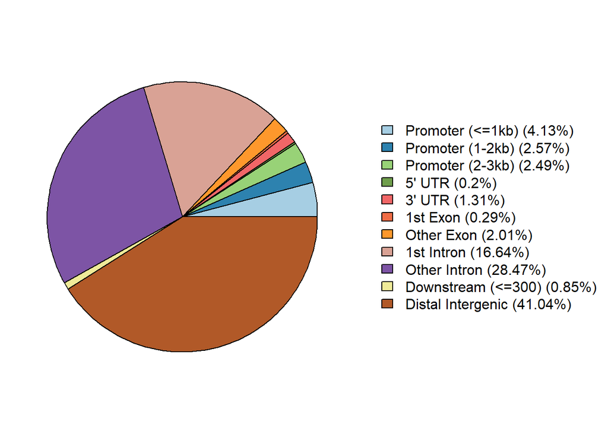

### Motif Analysis

RSAT was used to identify which motifs were enriched based on these peaks. The results can be found [here](http://rsat.sb-roscoff.fr/tmp/apache/2019/04/05/peak-motifs.2019-04-05.161943_2019-04-05.161943_uxnSkQ/peak-motifs_synthesis.html#merged_sites). The top five motifs are shown below.

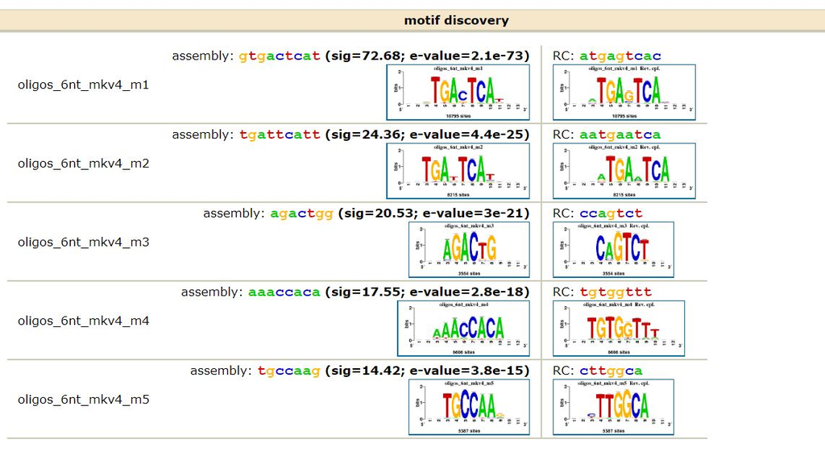

### Peak Integration

The resulting peaks were integrated with gene expression candidates by determining which candidates had a peak within 3,000 bp of the transcription start site (TSS). There were 240 differentially expressed candidates and 36 had a peak within 3,000 bp of the TSS.

### Enrichment Analysis

Enrichment analysis was then performed on these 36 genes using enrichR to determine if they are part of any known biological pathway or system. Using the GO Biological Process 2018 database, the top 10 processes with the smallest p-values are listed below.

| Process | Overlap | P-value |
| --- | --- | --- |
| cellular potassium ion homeostasis (GO:0030007) | 2/14 | 0.000283 |
| mitotic cell cycle arrest (GO:0071850) | 2/15 | 0.000326 |
| cellular monovalent inorganic cation homeostasis (GO:0030004) | 2/18 | 0.000473 |
| negative regulation of lymphocyte activation (GO:0051250) | 2/20 | 0.000586 |
| potassium ion homeostasis (GO:0055075) | 2/26 | 0.000996 |
| regulation of mitotic spindle checkpoint (GO:1903504) | 1/7 | 0.012534 |
| granzyme-mediated apoptotic signaling pathway (GO:0008626) | 1/7 | 0.012534 |
| negative regulation of meiotic cell cycle (GO:0051447) | 1/7 | 0.012534 |
| regulation of toll-like receptor 3 signaling pathway (GO:0034139) | 1/8 | 0.014312 |
| vascular smooth muscle contraction (GO:0014829) | 1/8 | 0.014312 |